# The R Inside Airbnb

Inside Airbnb is an anti-airbnb activist website that hosts airbnb listing availability data for many cities worldwide. The data is scraped from the airbnb website every few days or so, and represents listing information that was live at the time of the scrape. The goal of this notebook will be to explore a subset of the data and answer two primary questions: First, what factors drive host pricing decisions? Second, what factors drive customer booking decisions?

## Accessing the data

To access the data, I began by scraping the data file URLs from the Inside Airbnb website, and used those endpoints to construct a PostgreSQL database from the hosted csv files. Let’s source that library now:

```r
source("inside_airbnb_to_postgres.R")
```

Using this library, all of the csv file URLs can be organinzed into a table by calling:

```r
file_urls <- scrape_inside_airbnb()
head(file_urls)
```

|  | url_country | url_state | url_city | url_date | detailed_listings_url | summary_listings_url | calendar_url | detailed_review_url | summary_review_url | neighbourhood_url | neighbourhood_geo_url |
| --- | --- | --- | --- | --- | --- | --- | --- | --- | --- | --- | --- |
| 1 | the-netherlands | north-holland | amsterdam | 2020-02-14 | http://data.insideairbnb.com/the-netherlands/north-holland/amsterdam/2020-02-14/data/listings.csv.gz | http://data.insideairbnb.com/the-netherlands/north-holland/amsterdam/2020-02-14/visualisations/listings.csv | http://data.insideairbnb.com/the-netherlands/north-holland/amsterdam/2020-02-14/data/calendar.csv.gz | http://data.insideairbnb.com/the-netherlands/north-holland/amsterdam/2020-02-14/data/reviews.csv.gz | http://data.insideairbnb.com/the-netherlands/north-holland/amsterdam/2020-02-14/visualisations/reviews.csv | http://data.insideairbnb.com/the-netherlands/north-holland/amsterdam/2020-02-14/visualisations/neighbourhoods.csv | http://data.insideairbnb.com/the-netherlands/north-holland/amsterdam/2020-02-14/visualisations/neighbourhoods.geojson |
| 2 | the-netherlands | north-holland | amsterdam | 2020-01-05 | http://data.insideairbnb.com/the-netherlands/north-holland/amsterdam/2020-01-05/data/listings.csv.gz | http://data.insideairbnb.com/the-netherlands/north-holland/amsterdam/2020-01-05/visualisations/listings.csv | http://data.insideairbnb.com/the-netherlands/north-holland/amsterdam/2020-01-05/data/calendar.csv.gz | http://data.insideairbnb.com/the-netherlands/north-holland/amsterdam/2020-01-05/data/reviews.csv.gz | http://data.insideairbnb.com/the-netherlands/north-holland/amsterdam/2020-01-05/visualisations/reviews.csv | http://data.insideairbnb.com/the-netherlands/north-holland/amsterdam/2020-01-05/visualisations/neighbourhoods.csv | http://data.insideairbnb.com/the-netherlands/north-holland/amsterdam/2020-01-05/visualisations/neighbourhoods.geojson |
| 3 | the-netherlands | north-holland | amsterdam | 2019-12-07 | http://data.insideairbnb.com/the-netherlands/north-holland/amsterdam/2019-12-07/data/listings.csv.gz | http://data.insideairbnb.com/the-netherlands/north-holland/amsterdam/2019-12-07/visualisations/listings.csv | http://data.insideairbnb.com/the-netherlands/north-holland/amsterdam/2019-12-07/data/calendar.csv.gz | http://data.insideairbnb.com/the-netherlands/north-holland/amsterdam/2019-12-07/data/reviews.csv.gz | http://data.insideairbnb.com/the-netherlands/north-holland/amsterdam/2019-12-07/visualisations/reviews.csv | http://data.insideairbnb.com/the-netherlands/north-holland/amsterdam/2019-12-07/visualisations/neighbourhoods.csv | http://data.insideairbnb.com/the-netherlands/north-holland/amsterdam/2019-12-07/visualisations/neighbourhoods.geojson |
| 4 | the-netherlands | north-holland | amsterdam | 2019-11-03 | http://data.insideairbnb.com/the-netherlands/north-holland/amsterdam/2019-11-03/data/listings.csv.gz | http://data.insideairbnb.com/the-netherlands/north-holland/amsterdam/2019-11-03/visualisations/listings.csv | http://data.insideairbnb.com/the-netherlands/north-holland/amsterdam/2019-11-03/data/calendar.csv.gz | http://data.insideairbnb.com/the-netherlands/north-holland/amsterdam/2019-11-03/data/reviews.csv.gz | http://data.insideairbnb.com/the-netherlands/north-holland/amsterdam/2019-11-03/visualisations/reviews.csv | http://data.insideairbnb.com/the-netherlands/north-holland/amsterdam/2019-11-03/visualisations/neighbourhoods.csv | http://data.insideairbnb.com/the-netherlands/north-holland/amsterdam/2019-11-03/visualisations/neighbourhoods.geojson |
| 5 | the-netherlands | north-holland | amsterdam | 2019-10-15 | http://data.insideairbnb.com/the-netherlands/north-holland/amsterdam/2019-10-15/data/listings.csv.gz | http://data.insideairbnb.com/the-netherlands/north-holland/amsterdam/2019-10-15/visualisations/listings.csv | http://data.insideairbnb.com/the-netherlands/north-holland/amsterdam/2019-10-15/data/calendar.csv.gz | http://data.insideairbnb.com/the-netherlands/north-holland/amsterdam/2019-10-15/data/reviews.csv.gz | http://data.insideairbnb.com/the-netherlands/north-holland/amsterdam/2019-10-15/visualisations/reviews.csv | http://data.insideairbnb.com/the-netherlands/north-holland/amsterdam/2019-10-15/visualisations/neighbourhoods.csv | http://data.insideairbnb.com/the-netherlands/north-holland/amsterdam/2019-10-15/visualisations/neighbourhoods.geojson |
| 6 | the-netherlands | north-holland | amsterdam | 2019-09-14 | http://data.insideairbnb.com/the-netherlands/north-holland/amsterdam/2019-09-14/data/listings.csv.gz | http://data.insideairbnb.com/the-netherlands/north-holland/amsterdam/2019-09-14/visualisations/listings.csv | http://data.insideairbnb.com/the-netherlands/north-holland/amsterdam/2019-09-14/data/calendar.csv.gz | http://data.insideairbnb.com/the-netherlands/north-holland/amsterdam/2019-09-14/data/reviews.csv.gz | http://data.insideairbnb.com/the-netherlands/north-holland/amsterdam/2019-09-14/visualisations/reviews.csv | http://data.insideairbnb.com/the-netherlands/north-holland/amsterdam/2019-09-14/visualisations/neighbourhoods.csv | http://data.insideairbnb.com/the-netherlands/north-holland/amsterdam/2019-09-14/visualisations/neighbourhoods.geojson |

The full dataset consists of 7 table types, each with 2300 files. Let’s see what the most scraped countries, states and cities are.

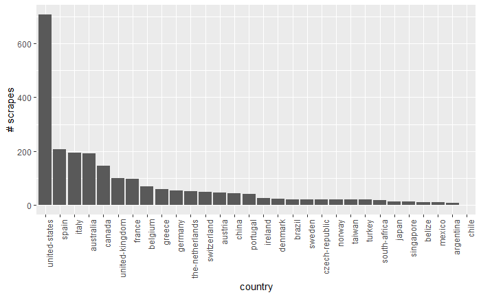

```r
scrapes_by_country <- file_urls %>%
  group_by(url_country) %>%
  summarize(num_scrapes = n()) %>%
  arrange(desc(num_scrapes)) %>% collect

options(repr.plot.height = 600)
ggplot(data = scrapes_by_country, aes(x = reorder(url_country, -num_scrapes), y = num_scrapes)) +
  geom_bar(stat = "identity") +
  xlab('country') + ylab('# scrapes') +
  theme(axis.text.x = element_text(angle = 90, hjust = 1))
```

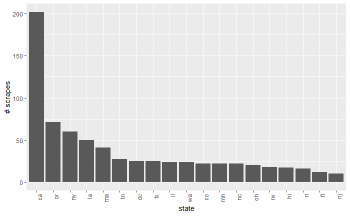

```r
scrapes_by_state <- file_urls %>%
  filter(url_country == "united-states") %>%
  group_by(url_state) %>%
  summarize(num_scrapes = n()) %>%
  arrange(desc(num_scrapes)) %>% collect

options(repr.plot.height = 600)
ggplot(data = scrapes_by_state, aes(x = reorder(url_state, -num_scrapes), y = num_scrapes)) +
  geom_bar(stat = "identity") +
  xlab('state') + ylab('# scrapes') +
  theme(axis.text.x = element_text(angle = 90, hjust = 1))
```

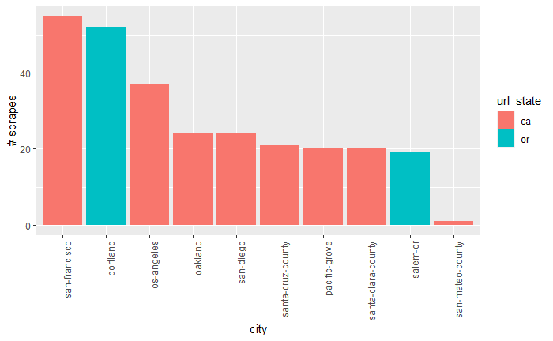

```r
scrapes_by_city <- file_urls %>%
  filter(url_country == "united-states" & url_state == "ca" | url_state == "or") %>%
  group_by(url_city, url_state) %>%
  summarize(num_scrapes = n()) %>%
  arrange(desc(num_scrapes)) %>% collect

options(repr.plot.height = 600)
ggplot(data = scrapes_by_city, aes(x = reorder(url_city, -num_scrapes), y = num_scrapes, fill = url_state)) +
  geom_bar(stat = "identity") +
  xlab('city') + ylab('# scrapes') +
  theme(axis.text.x = element_text(angle = 90, hjust = 1))
```

## Building a database

As we can see, San Francisco and Portland are two of the most scraped cities in the dataset. From here on, we’ll restrict the analysis to these two cities. Let’s go ahead and connect to the PostgreSQL database:

```r
library(DBI)
con <- DBI::dbConnect(odbc::odbc(), Driver = "PostgreSQL ODBC Driver(ANSI)",
    Server = "localhost", Database = "inside_airbnb", UID = rstudioapi::askForPassword("Database user"),
    PWD = rstudioapi::askForPassword("Database password"), Port = 5432)
tmp <- dbExecute(con, "SET CLIENT_ENCODING TO 'utf8'")
```

We can populate the database with any list of cities and table types by running the code chunk below; however, downloading and converting the files takes some time, so this was done ahead of time.

```r
cities <- list("san-francisco", "portland")
table_names <- list("summary_listings", "calendar", "detailed_review", "detailed_listings", "summary_review", "neighbourhood")
# num_rows_affected <- build_pgdb(con, cities = cities, table_names = table_names)
```

The two main tables of interest are “calendar” which contains the listing prices and availabilities for the upcoming year, and “detailed_listings” which contains some features for each listing (e.g., host, location, property details, etc.). Let’s run some simple queries to see how many listings we have for each city:

```sql
SELECT smart_location, COUNT(DISTINCT id)
FROM detailed_listings
GROUP BY smart_location;
```

```r
num_listings
```

| smart_location | count |
| --- | --- |
| Bernal Heights, San Francisco, CA | 1 |
| Daly City, CA | 44 |
| Happy Valley, OR | 1 |
| Hillsboro, OR | 1 |
| Lake Oswego, OR | 1 |
| Noe Valley - San Francisco, CA | 1 |
| Portland | 1 |
| Portland , OR | 3 |
| Portland, OR | 4672 |
| San Francico, CA | 1 |

[output cut: 8 more lines]

```r
sql_count_cols <- "SELECT COUNT(*) FROM information_schema.columns
                  WHERE table_name = 'detailed_listings'"
num_features <- as.integer(dbGetQuery(con, sql_count_cols)$count)
sql_count_records <- "SELECT COUNT(*) FROM calendar"
num_records <- as.integer(dbGetQuery(con, sql_count_records)$count)
```

Uh oh… it appears the cities weren’t coded very well. Overall, “detailed_listings” has 106 features, and many of them either aren’t coded very well, or contain redundant or irrelevant information for our purposes. Also, the data is pretty big… the “calendar” table has 4842090 records across all listings and dates. We’re going to need to do some data cleansing and filtering to obtain something more reasonable to work with.

## Cleaning and preprocessing

Let’s go ahead and read in “detailed listings” and decided which features are worth keeping.

```r
detailed_listings <- dbReadTable(con, "detailed_listings")
head(detailed_listings)
```

|  | id | listing_url | scrape_id | last_scraped | name | summary | space | description | experiences_offered | neighbourhood_overview | notes | transit | access | interaction | house_rules | thumbnail_url | medium_url | picture_url | xl_picture_url | host_id | host_url | host_name | host_since | host_location | host_about | host_response_time | host_response_rate | host_acceptance_rate | host_is_superhost | … |
| --- | --- | --- | --- | --- | --- | --- | --- | --- | --- | --- | --- | --- | --- | --- | --- | --- | --- | --- | --- | --- | --- | --- | --- | --- | --- | --- | --- | --- | --- | --- |
| 1 | 958 | https://www.airbnb.com/rooms/958 | 20200212052255 | 2020-02-12 | Bright, Modern Garden Unit - 1BR/1B | New update: the house next door is under construction and there is the possibility of noise from 7am - 5pm. Our rates are discounted during this time period. Our bright garden unit overlooks a grassy … | Newly remodeled, modern, and bright garden unit in historic Victorian home. *New fixtures and finishes. *Organic cotton sheets and towels. *Zero VOC and non-toxic Yolo paint. *Organic and fair-trade t… | New update: the house next door is under construction and there is the possibility of noise from 7am - 5pm. Our rates are discounted during this time period. Our bright garden unit overlooks a grassy … | none | *Quiet cul de sac in friendly neighborhood *Steps away from grassy park with 2 playgrounds and Recreational Center *Very family-friendly neighborhood *Quaint shops, grocery stores and restaurants all … | Due to the fact that we have children and a dog, we are up early 7-8am and their footsteps or paws can be heard from the apartment. Our place is ideal for early risers or hard sleepers who appreciate … | *Public Transportation is 1/2 block away. *Centrally located with easy access to major lines of public transportation (N-Judah, Haight #7, J-Church, Fillmore, and Bart) *No Parking is offered. *Street… | *Full access to patio and backyard (shared with us and our dog who live upstairs) *Beautiful garden with fruit trees, native plants and lawn *Washer and dryer *Children's toys *Charcoal grill | A family of 4 lives upstairs with their dog. Normally we are able to meet guests, but we like to give people their privacy and mostly leave them alone. We are always available if anything is needed or… | * No Pets - even visiting guests for a short time period. * No Smokers allowed - even if smoking off premises. | NA | NA | https://a0.muscache.com/im/pictures/b7c2a199-4c17-4ba6-b81d-751719d2dac6.jpg?aki_policy=large | NA | 1169 | https://www.airbnb.com/users/show/1169 | Holly | 2008-07-31 | San Francisco, California, United States | We are a family with 2 boys born in 2009 and 2011. We have a new puppy (Feb 2017) named Tucker who is part black lab and part border collie. | within an hour | 100% | 99% | t | … |
| 2 | 5858 | https://www.airbnb.com/rooms/5858 | 20200212052255 | 2020-02-12 | Creative Sanctuary |  | We live in a large Victorian house on a quiet street, nestled between the Mission district and Noe Valley. We're one block from the streetcar stop and five blocks from the subway. We have three bedroo… | We live in a large Victorian house on a quiet street, nestled between the Mission district and Noe Valley. We're one block from the streetcar stop and five blocks from the subway. We have three bedroo… | none | I love how our neighborhood feels quiet but is so close to lots of hustle and bustle. There is the train nearby that takes you straight downtown and we are smack in the middle of Noe Valley (quiet and… | All the furniture in the house was handmade so there is a very special feeling there. We love living here and hope that others feel the same. | The train is two blocks away and you can stop and get a coffee on your way there :) | Our deck, garden, gourmet kitchen and extensive art, design and literature library. |  | Please respect the house, the art work, the furniture and have fun! | NA | NA | https://a0.muscache.com/im/pictures/17714/3a7aea10_original.jpg?aki_policy=large | NA | 8904 | https://www.airbnb.com/users/show/8904 | Philip And Tania | 2009-03-02 | San Francisco, California, United States | Philip: English transplant to the Bay Area and half Spanish adoptive son of hardworking Yorkshire folk. I'm married to the one, engaged to my work and in love with exploring the merging of design art … | within a day | 90% | 82% | f | … |
| 3 | 7918 | https://www.airbnb.com/rooms/7918 | 20200212052255 | 2020-02-12 | A Friendly Room - UCSF/USF - San Francisco | Nice and good public transportation. 7 minutes walk to UCSF. 15 minutes walk to USF, ST Mary Hospital Room rental-sunny view room/sink/Wi Fi (inner sunset / UCSF) (map) The place is located within wal… | Settle down, S.F. resident, student, hospital, job relocated, rotation. Monthly rental, short term staying - Nice public transportation location. No tourist or transient. No pet no smoking no party in… | Nice and good public transportation. 7 minutes walk to UCSF. 15 minutes walk to USF, ST Mary Hospital Room rental-sunny view room/sink/Wi Fi (inner sunset / UCSF) (map) The place is located within wal… | none | Shopping old town, restaurants, McDonald, Whole food & Target stores. | Wi-Fi signal in common areas. Large eat in kitchen. Sunny sitting room. Please email your current official picture id with print name (SF school resident id)and job/school offer letter/apply school le… | N Juda Muni and bus stop. Street parking. |  |  | No party, No smoking, not for any kinds of smoking, no candle, no tourist, no transient. | NA | NA | https://a0.muscache.com/im/pictures/26356/8030652f_original.jpg?aki_policy=large | NA | 21994 | https://www.airbnb.com/users/show/21994 | Aaron | 2009-06-17 | San Francisco, California, United States | 7 minutes walk to UCSF hospital & school campus. 15 minutes walk to USF, St. Mary Hospital. 5 minute walk to Goldern Gate Park/Whole food/ regular food store and many different style restaurants & sto… | within an hour | 100% | 86% | t | … |
| 4 | 8142 | https://www.airbnb.com/rooms/8142 | 20200212052255 | 2020-02-12 | Friendly Room Apt. Style -UCSF/USF - San Francisco | Nice and good public transportation. 7 minutes walk to UCSF. 15 minutes walk to USF, ST Mary Hospital Room rental-sunny view room/sink/Wi Fi (inner sunset / UCSF) (map) The place is located within wal… | Settle down, S.F. resident, student, hospital, job relocated, rotation. Monthly rental, short term staying - Nice public transportation location. No tourist or transient. No pet no smoking no party in… | Nice and good public transportation. 7 minutes walk to UCSF. 15 minutes walk to USF, ST Mary Hospital Room rental-sunny view room/sink/Wi Fi (inner sunset / UCSF) (map) The place is located within wal… | none |  | Wi-Fi signal in common areas. Large eat in kitchen. Sunny sitting room. Please email your current official picture id with print name (SF school resident id)and job/school offer letter/apply school le… | N Juda Muni, Bus and UCSF Shuttle. small shopping town. McDonald, Whole food & regular food store. |  |  | no pet no smoke no party inside the building | NA | NA | https://a0.muscache.com/im/pictures/27832/3b1f9e5e_original.jpg?aki_policy=large | NA | 21994 | https://www.airbnb.com/users/show/21994 | Aaron | 2009-06-17 | San Francisco, California, United States | 7 minutes walk to UCSF hospital & school campus. 15 minutes walk to USF, St. Mary Hospital. 5 minute walk to Goldern Gate Park/Whole food/ regular food store and many different style restaurants & sto… | within an hour | 100% | 86% | t | … |
| 5 | 8339 | https://www.airbnb.com/rooms/8339 | 20200212052255 | 2020-02-12 | Historic Alamo Square Victorian | Pls email before booking. Interior featured in magazines. Listed historic with the City of SF. Steps away from the iconic Alamo Square "Painted Ladies". | Please send us a quick message before booking :) Victorian flat in Queen Ann Victorian. Interior featured in magazines. Listed historic with the City of San Francisco. Steps away from the iconic Alamo… | Pls email before booking. Interior featured in magazines. Listed historic with the City of SF. Steps away from the iconic Alamo Square "Painted Ladies". Please send us a quick message before booking :… | none |  | tax ID on file tax ID on file |  | Guests have access to everything listed and shown. |  | House Manual and House Rules will be provided after initial communication, when we work out that the exact timing and use are suitable for both parties House Manual and House Rules will be provided af… | NA | NA | https://a0.muscache.com/im/pictures/213fbf05-3545-4ca5-9db0-43022ea24d56.jpg?aki_policy=large | NA | 24215 | https://www.airbnb.com/users/show/24215 | Rosy | 2009-07-02 | San Francisco, California, United States | I'm an Interior Stylist living in SF. \r\n\r\n\r\n | within a few hours | 100% | 43% | f | … |
| 6 | 8739 | https://www.airbnb.com/rooms/8739 | 20200212052255 | 2020-02-12 | Mission Sunshine, with Private Bath | Welcome to "The Mission," the sunniest neighborhood in town. Enjoy world-class dining, shopping, and nightlife on Valencia, or a Tartine picnic in Dolores Park, all just steps from our 100 year old ho… | Your sunny room looks out over a lush garden, and includes all the comforts of home... Queen bed, sofa, dresser, closet, and a rocking chair. Just up the hall, your private bathroom has a "like rain" … | Welcome to "The Mission," the sunniest neighborhood in town. Enjoy world-class dining, shopping, and nightlife on Valencia, or a Tartine picnic in Dolores Park, all just steps from our 100 year old ho… | none | Located between Valencia Street and Dolores Park, we are in a great location for exploring the Mission, as well as the rest of San Francisco. It's an easy walk to the Castro, Haight Street, Hayes Vall… | We live in a dense, urban neighborhood, and our home is 100 years old, with creaky stairs and floors, and very little sound insulation. There are neighbors all around, including directly above, so you… | It's an easy and enjoyable 10 minute stroll to the 16th St/Mission BART Station, and there are Muni Routes all around us, so there's easy access to SFO, Union Square, Moscone Center, Market Street, th… | You'll have your own bedroom and private bathroom, as well as shared access to our living room and sunporch. In the kitchen, you are free to store food in the refrigerator, use the microwave, and make… | We are experienced Airbnb hosts, and have had 100's of guests before you. We'll happily point you toward the traditional tourist sites or the hidden hotspots, whatever your preference. Guest interacti… | PLEASE READ: By booking, you agree to all of the following rules. If there are too many rules for you to read through, please consider another listing! (These rules have evolved over our 10+ years of … | NA | NA | https://a0.muscache.com/im/pictures/80811/7a57d0e7_original.jpg?aki_policy=large | NA | 7149 | https://www.airbnb.com/users/show/7149 | Ivan & Wendy | 2009-01-27 | San Francisco, California, United States | Ivan is a publisher of a book for 4 year olds. (Look for "Four is a little, Four is a LOT" or "fourlosophy".) Wendy is an elementary school teacher. And Milo is a 25 pound mutt. (Terrier...? Chihuahua… | within an hour | 100% | 99% | t | … |

A number of columns are mostly missing data (i.e., NA’s), have only one distinct value, or are URL’s. We can drop those, and some other features we may not care about such as the scrape id, etc. We’ll drop all but one of the city features and factorize the remaining feature. We also recode all features with mosly t’s ad f’s to boolean. Many of the features are long text descriptions. While we could apply some NLP or sentiment analysis to these entries to construct new features, we’ll keep things simple and convert these to numeric values corresponding to the length of the entry. This should greatly reduce the size of the data but also throws away a good deal of information. We can always return to beef up the feature count here. Also, some of the URL’s link to important data such as pictures of the rental units. We’ll ignore those for now as well, but may return to them in the future.

```r
source("data_cleaning_utils.R")

detailed_listings <- detailed_listings %>%
  drop_junk %>%
  factorize_booleans %>%
  factorize_city(city_names = c("Portland","San Francisco"), state_names = c("OR","CA")) %>%
  factorize_amenities %>%
  factorize_host_verifications %>%
  factorize_license %>%
  factorize_simple_cols %>%
  factorize_cancellation_policy %>%
  refactor_property_types %>%
  refactor_bed_type %>%
  convert_dates %>%
  host_rates_to_numeric %>%
  text_to_numeric %>%
  process_missing


head(detailed_listings)
```

|  | id | name | summary | space | description | neighbourhood_overview | notes | transit | access | interaction | house_rules | host_since | host_location | host_about | host_response_time | host_response_rate | host_acceptance_rate | host_is_superhost | host_total_listings_count | host_has_profile_pic | host_identity_verified | neighbourhood_cleansed | zipcode | smart_location | latitute | longitude | is_location_exact | property_type | room_type | … |
| --- | --- | --- | --- | --- | --- | --- | --- | --- | --- | --- | --- | --- | --- | --- | --- | --- | --- | --- | --- | --- | --- | --- | --- | --- | --- | --- | --- | --- | --- | --- |
| 1 | 958 | 35 | 406 | 371 | 1000 | 225 | 239 | 499 | 191 | 231 | 110 | 4243 | San Francisco | 141 | within an hour | 4 | 99 | t | 1 | t | t | Western Addition | 94117 | San Francisco | 37.76931 | -122.4339 | t | apartment | Entire home/apt | … |
| 2 | 5858 | 18 | 0 | 913 | 1000 | 320 | 142 | 84 | 83 | 0 | 67 | 4029 | San Francisco | 547 | within a day | 2 | 82 | f | 2 | t | t | Bernal Heights | 94110 | San Francisco | 37.74511 | -122.4210 | t | apartment | Entire home/apt | … |
| 3 | 7918 | 42 | 249 | 1000 | 1000 | 69 | 327 | 42 | 0 | 0 | 88 | 3922 | San Francisco | 1069 | within an hour | 4 | 86 | t | 10 | t | t | Haight Ashbury | 94117 | San Francisco | 37.76669 | -122.4525 | t | apartment | Private room | … |
| 4 | 8142 | 50 | 249 | 1000 | 1000 | 0 | 327 | 98 | 0 | 0 | 44 | 3922 | San Francisco | 1069 | within an hour | 4 | 86 | t | 10 | t | t | Haight Ashbury | 94117 | San Francisco | 37.76487 | -122.4518 | t | apartment | Private room | … |
| 5 | 8339 | 31 | 153 | 970 | 1000 | 0 | 29 | 0 | 51 | 0 | 303 | 3907 | San Francisco | 44 | within a few hours | 4 | 43 | f | 2 | t | t | Western Addition | 94117 | San Francisco | 37.77525 | -122.4364 | t | other | Entire home/apt | … |
| 6 | 8739 | 35 | 495 | 432 | 1000 | 1000 | 1000 | 690 | 432 | 470 | 1000 | 4063 | San Francisco | 585 | within an hour | 4 | 99 | t | 2 | t | f | Mission | 94110 | San Francisco | 37.75919 | -122.4224 | t | other | Private room | … |

## Exploratory Data Analysis

Let’s do some simple eda to verify the cleaning steps, and get a sense how the variables are distribtued and correlated.

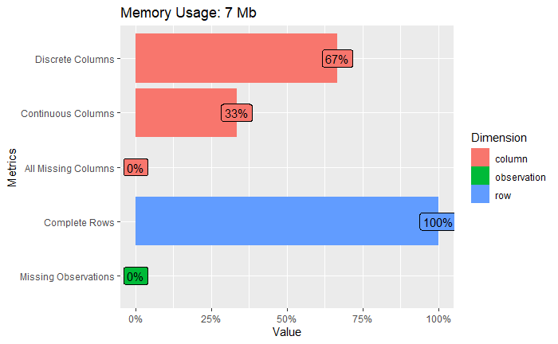

```r
suppressMessages(library(DataExplorer))
plot_intro(detailed_listings)
```

[output not shown]

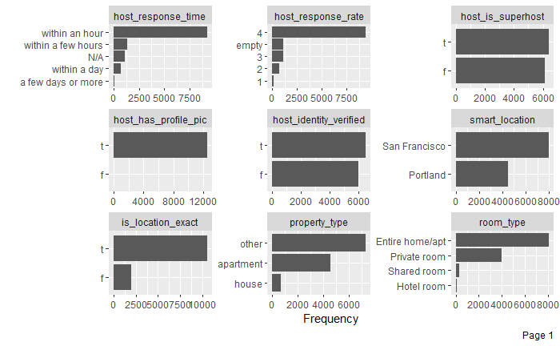

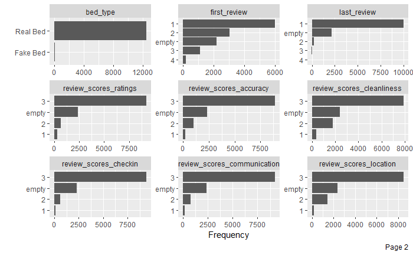

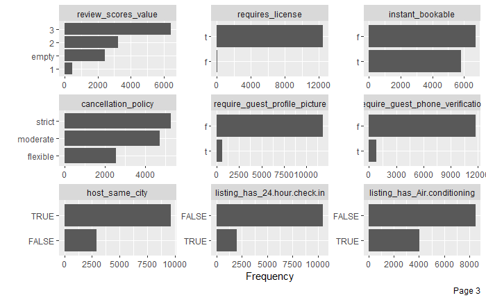

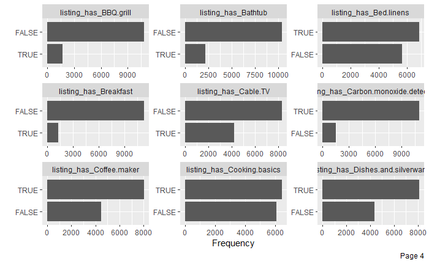

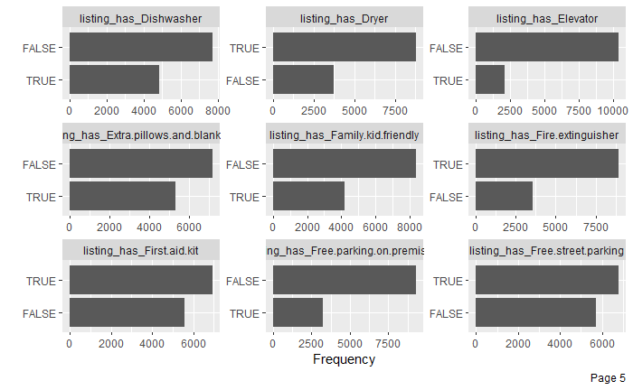

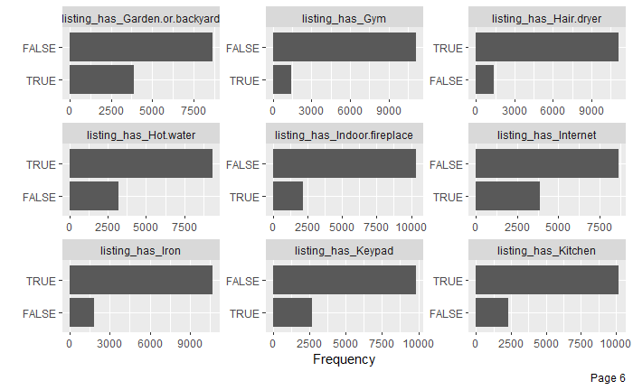

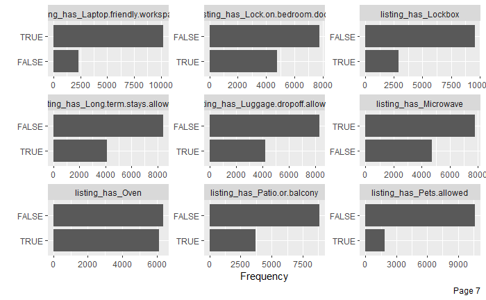

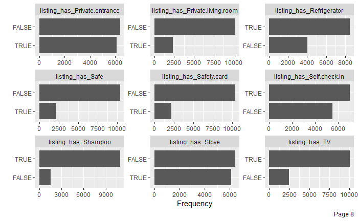

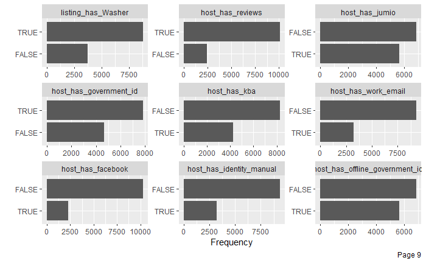

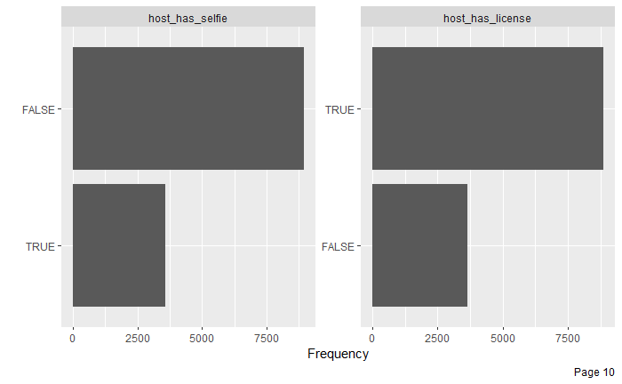

```r
plot_bar(detailed_listings)
```

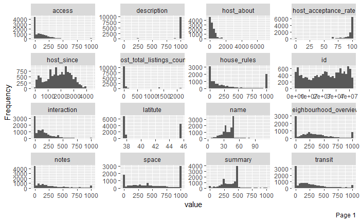

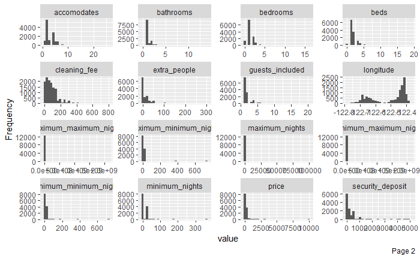

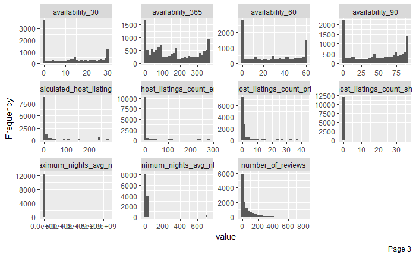

```r
plot_histogram(detailed_listings)
```

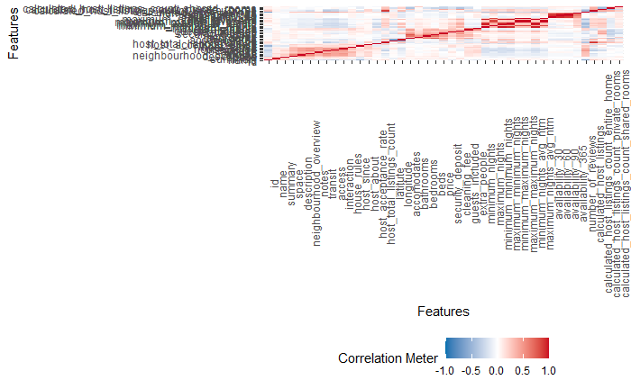

```r
plot_correlation(detailed_listings, type = 'continuous', cor_args = list("method" = "spearman"))
```

[output not shown]

[figure not shown]

```r
plot_correlation(detailed_listings, type = 'discrete', cor_args = list("method" = "spearman"))
```

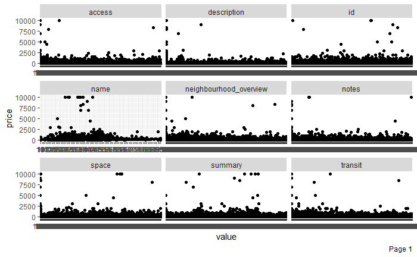

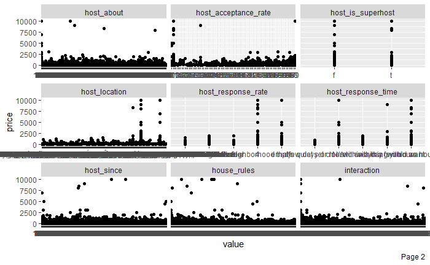

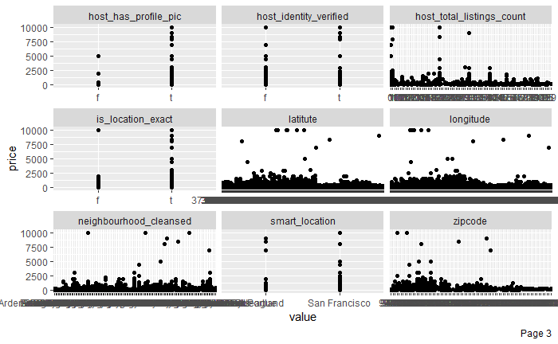

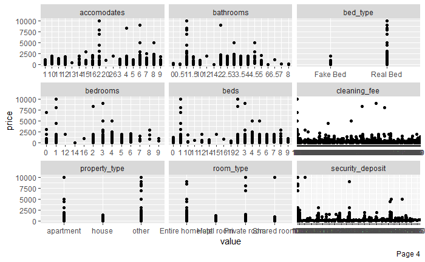

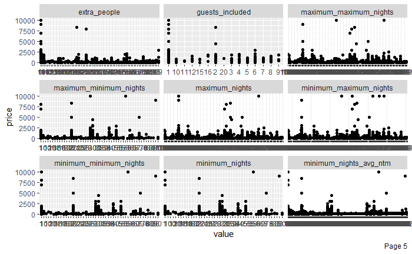

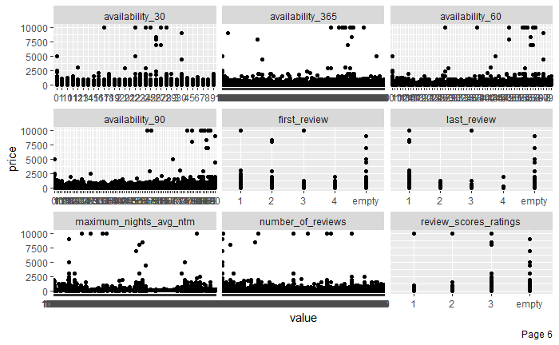

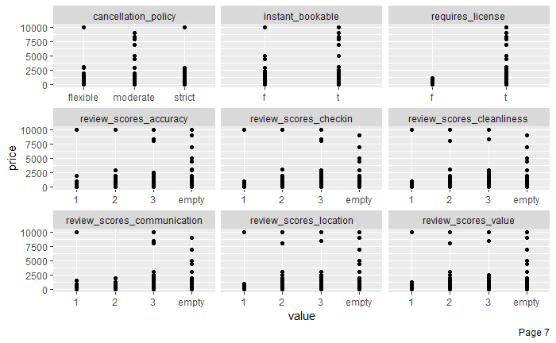

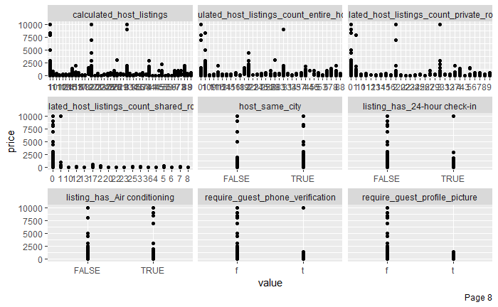

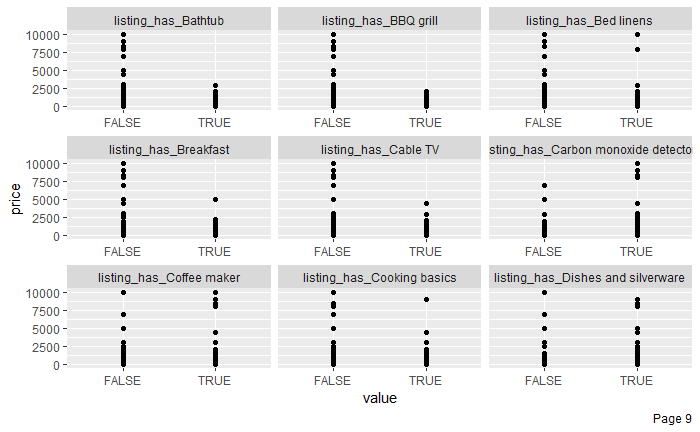

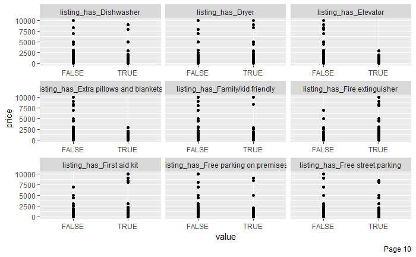

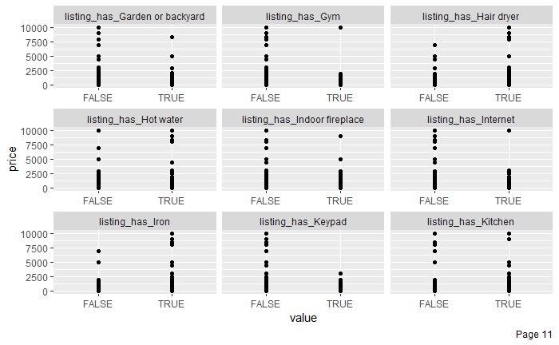

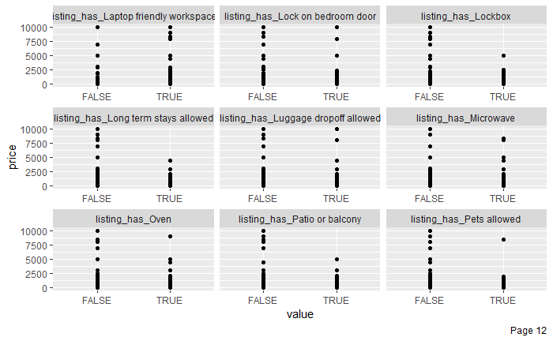

[3 more figures not shown]

```r
# numeric_cols <- sapply(detailed_listings, function(x) is.numeric(x))
# plot_prcomp(detailed_listings[,numeric_cols], variance_cap = 0.5, maxcat = 10L)
# plot_qq(detailed_listings)
plot_scatterplot(detailed_listings, by = "price")
```

```r
NA
```

Now let’s read in the calendar table and performing an inner join with some of the cleaned detailed listings features from above that we might want to include:

```r
suppressMessages(library("timeDate"))

calendar <- dbReadTable(con, "calendar")
calendar$date <- as.Date(calendar$date)
calendar$available <- as.factor(calendar$available)
features <- c('accomodates', 'cleaning_fee',
              'extra_people', 'number_of_reviews',
              'bathrooms', 'security_deposit',
              'neighbourhood_cleansed', 'calculated_host_listings',
              'smart_location')

full_df <- calendar %>%
  inner_join(detailed_listings[,c("id", features)], by = c("listing_id" = "id")) %>%
  select(-c('adjusted_price')) %>%
  mutate(num_date = as.numeric(date),
         weekday = as.factor(weekdays(date)),
         is_holiday = as.factor(isHoliday(as.timeDate(date))),
         listing_id = as.factor(listing_id),
         neighbourhood_cleansed = as.factor(neighbourhood_cleansed))
full_df <- full_df[complete.cases(full_df),]

rm(detailed_listings, calendar)
head(full_df)
```

|  | listing_id | date | available | price | minimum_nights | maximum_nights | accomodates | cleaning_fee | extra_people | number_of_reviews | bathrooms | security_deposit | neighbourhood_cleansed | calculated_host_listings | smart_location | num_date | weekday | is_holiday |
| --- | --- | --- | --- | --- | --- | --- | --- | --- | --- | --- | --- | --- | --- | --- | --- | --- | --- | --- |
| 1 | 5858 | 2020-02-12 | t | 235 | 30 | 60 | 5 | 100 | 0 | 111 | 1 | 0 | Bernal Heights | 1 | San Francisco | 18304 | Wednesday | FALSE |
| 2 | 958 | 2020-02-12 | f | 135 | 1 | 30 | 3 | 100 | 25 | 233 | 1 | 100 | Western Addition | 1 | San Francisco | 18304 | Wednesday | FALSE |
| 3 | 958 | 2020-02-13 | f | 135 | 1 | 30 | 3 | 100 | 25 | 233 | 1 | 100 | Western Addition | 1 | San Francisco | 18305 | Thursday | FALSE |
| 4 | 958 | 2020-02-14 | f | 135 | 1 | 30 | 3 | 100 | 25 | 233 | 1 | 100 | Western Addition | 1 | San Francisco | 18306 | Friday | FALSE |
| 5 | 958 | 2020-02-15 | f | 135 | 1 | 30 | 3 | 100 | 25 | 233 | 1 | 100 | Western Addition | 1 | San Francisco | 18307 | Saturday | TRUE |
| 6 | 958 | 2020-02-16 | f | 135 | 1 | 30 | 3 | 100 | 25 | 233 | 1 | 100 | Western Addition | 1 | San Francisco | 18308 | Sunday | TRUE |

Now we can do a slightly more detailed eda.

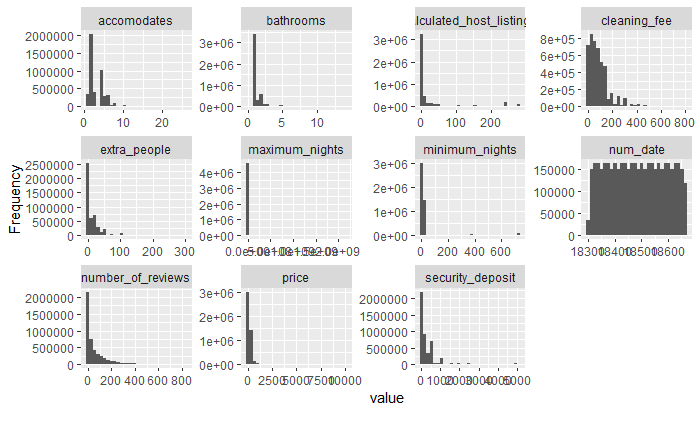

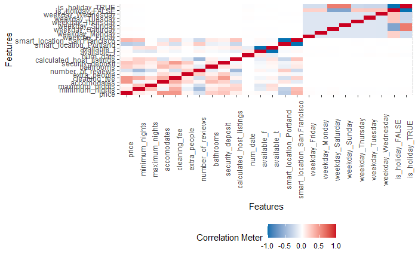

```r
suppressMessages(library(DataExplorer))
suppressWarnings({
  plot_histogram(full_df)
  plot_correlation(full_df, cor_args = list("method" = "spearman"))
})
```

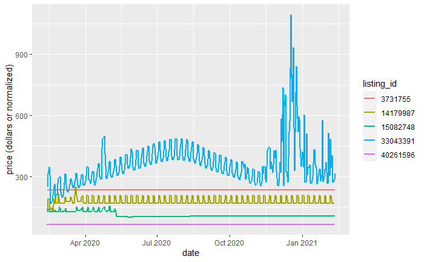

```r
num_listings <- 5
sample_df <- full_df %>%
  filter(listing_id %in% sample(unique(listing_id), num_listings, replace = FALSE)) %>%
  group_by(listing_id) #%>%
  # mutate(price = price / median(price))
options(repr.plot.height = 600)
ggplot(data = sample_df, aes(x = date, y = price, group = listing_id, color = listing_id)) +
  geom_line(size = 1) +
  xlab('date') + ylab('price (dollars or normalized)')
```

From these visualizations, we can tell that price dynamics vary substantially from listing to listing and many appear non-stationary. Predictions will be better if we can identify groups of similarly behaving listings and model them separately. We’ll try clustering the time series’ power spectra:

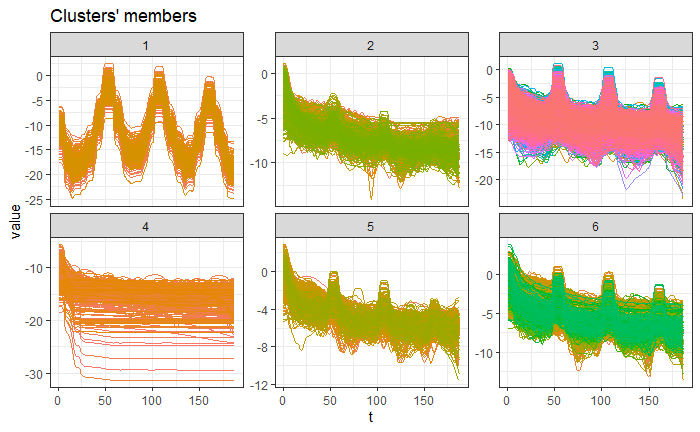

```r
suppressMessages({
  library(umap)
  library(dtwclust)
})


#get complete calendars
calendars <- full_df %>%
  group_by(listing_id) %>%
  mutate(price = log(price + 1)) %>%
  mutate(price = price - mean(price)) %>%
  ungroup %>%
  pivot_wider(id_cols = listing_id,
              values_from = price,
              names_from = date,
              values_fill = list(price = 0))
calendars <- calendars[complete.cases(calendars),]
calendars <- calendars[,colSums(is.na(calendars)) == 0]
calendars <- as.matrix(calendars[,2:366])
calendars <- calendars[rowSums(calendars == 0) < ncol(calendars),]

#get multitapered power spectra
calendars_df <- as.data.frame(t(calendars))
specs <- map(calendars_df, ts) %>%
  map(spectrum, plot = FALSE, span = 10) %>%
  map(purrr::pluck, "spec")
freqs <- map(calendars_df, ts) %>%
  map(spectrum, plot = FALSE, span = 10) %>%
  map(purrr::pluck, "freq")
specs <- log(t(matrix(replace_na(unlist(specs),0), ncol = ncol(calendars_df))))
# specs <- apply(specs, 2, function(x) x / sum(x))

#clustering via time series clustering approach (pam w/ dtw distance)
spec_clust <- tsclust(specs,
                 type = "tadpole",
                 k = 6,
                 control = tadpole_control(dc = 0.1, window.size = 10))
cal_clust <- tsclust(calendars,
                 type = "tadpole",
                 k = 6,
                 control = tadpole_control(dc = 0.1, window.size = 4))
plot(spec_clust, type = 'sc', linetype = 'solid')
```

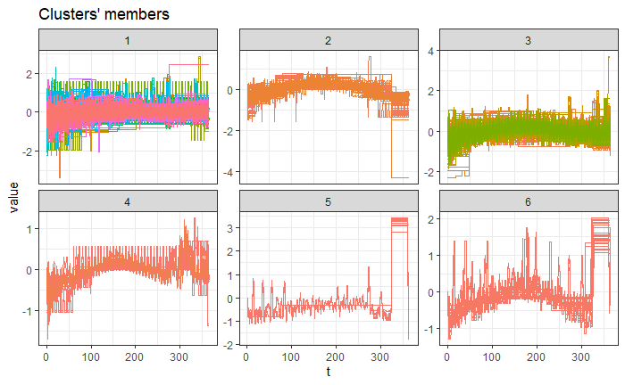

```r
plot(cal_clust, type = 'sc', linetype = 'solid')
```

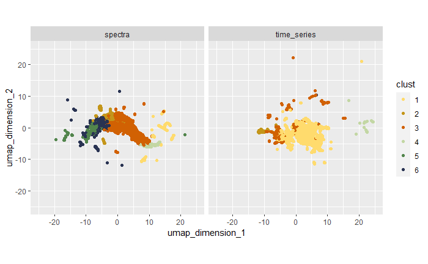

```r
#dimensionality reduction (pca or umap)
# comps <- prcomp(specs, scale = TRUE, center = TRUE)
umapped_specs <- umap(specs)
umapped_cals <- umap(calendars)
umap_df <- data.frame('umap_dimension_1' = c(umapped_specs$layout[,1],
                                             umapped_cals$layout[,1]),
                      'umap_dimension_2' = c(umapped_specs$layout[,2],
                                             umapped_cals$layout[,2]),
                      'clust' = factor(c(spec_clust@cluster,
                                         cal_clust@cluster)),
                      'type' = factor(rep(c("spectra","time_series"), each = nrow(specs))))
colors <- c("#FFDB6D", "#C4961A", "#D16103", "#C3D7A4", "#52854C", "#293352", "#F4EDCA", "#4E84C4")
plt <- ggplot(data = umap_df, aes(x = umap_dimension_1, y = umap_dimension_2, group = clust, color = clust)) +
  geom_point(size = 1.5) +
  scale_colour_manual(values = colors) +
  facet_grid(.~type) +
  coord_fixed() +
  xlim(-25, 25) + ylim(-25, 25)
suppressWarnings(print(plt))
```

## Predicting Advertised Price

Our goal will now be to predict listing price across the calendar year using features chosen based on the above eda.

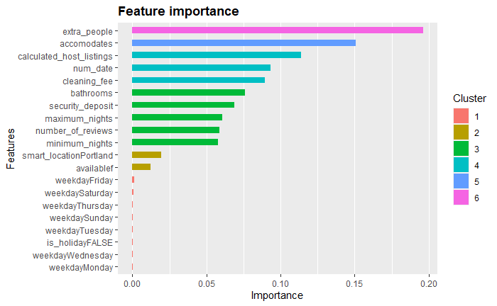

```r
suppressMessages({
  library(xgboost)
  library(glmnet)
  library(mlr)
  library(Ckmeans.1d.dp)
})

#select features and target
features <- c("available","minimum_nights",
              "maximum_nights","accomodates",
              "cleaning_fee","extra_people",
              "number_of_reviews","bathrooms",
              "security_deposit","calculated_host_listings",
              "smart_location", "weekday",
              "is_holiday", "num_date")
full_df$log_price <- (full_df$price + 1)

#breakup training and test sets
test_frac <- 0.15
train_listings <- c()
for (city in levels(full_df$smart_location)){
  city_listings <- unique(full_df$listing_id[full_df$smart_location == city])
  num_city_listings <- length(city_listings)
  train_listings <- c(train_listings,
                     sample(city_listings,
                            floor(test_frac*num_city_listings),
                            replace = FALSE))
}

#prepare training and test sets for xgboost
train_idx <- as.integer(full_df$listing_id) %in% train_listings
test_idx <- !(as.integer(full_df$listing_id) %in% train_listings)
xgtrain <- xgb.DMatrix(data = makeX(full_df[train_idx, features],
                                    sparse = TRUE),
                       label = full_df$log_price[train_idx])

xgtest <- xgb.DMatrix(data = makeX(full_df[test_idx, features],
                                   sparse = TRUE),
                      label = full_df$log_price[test_idx])

#xgboost cross validation parameters
cvparams <- list(booster = "gbtree",
                 objective = "reg:squarederror",
                 eta=0.3,
                 gamma=0,
                 max_depth=10)

#k-fold cross-validated xgboost
#take folds by sampling listings as above
num_folds <- 5
folds <- vector("list", num_folds)
for (fold in 1:num_folds){
  fold_indices <- c()
  for (city in levels(full_df$smart_location)){
    city_listings <- unique(full_df$listing_id[full_df$smart_location[train_idx] == city])
    num_city_listings <- length(city_listings)
    sample_listings <-   sample(city_listings,
                         floor(test_frac*num_city_listings),
                         replace = FALSE)
    fold_indices <- c(fold_indices, which(full_df$listing_id[train_idx] %in% sample_listings))
  }
  folds[[fold]] <- fold_indices
}

xgbcv <- xgb.cv(params = cvparams,
                data = xgtrain,
                nrounds = 300,
                folds = folds,
                showsd = T,
                print_every_n = 10,
                verbose = FALSE,
                early_stopping_rounds = 20,
                maximize = F)

xgmod <- xgb.train(data = xgtrain,
                  params = cvparams,
                  nrounds = xgbcv$best_iteration,
                  print_every_n = 10,
                  verbose = FALSE,
                  watchlist = list(val= xgtest,train = xgtrain))

xgpred <- predict(xgmod, xgtest)

# hyper paramater tuning (Not Run)
#
# train_task <- makeRegrTask(id = "1",
#                            data = full_df[!(as.integer(full_df$listing_id) %in% test_listings),][,c(features,'log_price')],
#                            target = "log_price")
# test_task <- makeRegrTask(id = "2",
#                           data = full_df[as.integer(full_df$listing_id) %in% test_listings,][,c(features,'log_price')],
#                           target = "log_price")
# train_task <- createDummyFeatures (obj = train_task)
# test_task <- createDummyFeatures (obj = test_task)
# xglearner <- makeLearner("regr.xgboost",
#                          predict.type = "response")
# xglearner$par.vals <- list(objective="reg:squarederror",
#                            eval_metric="error",
#                            nrounds=300L,
#                            eta=0.3)
# tune_params <- makeParamSet(makeDiscreteParam("booster", values = c("gbtree","gblinear")),
#                        makeIntegerParam("max_depth",lower = 5L, upper = 15L),
#                        makeNumericParam("min_child_weight",lower = 1L,upper = 10L),
#                        makeNumericParam("subsample",lower = 0.5,upper = 1),
#                        makeNumericParam("colsample_bytree",lower = 0.5,upper = 1))
# rdesc <- makeResampleDesc("CV", iters = 5L)
# ctrl <- makeTuneControlRandom(maxit = 10L)
# xgtune <- tuneParams(learner = xglearner,
#                      task = train_task,
#                      resampling = rdesc,
#                      par.set = tune_params,
#                      control = ctrl,
#                      show.info = T)
# best_tune <- setHyperPars(xglearner, par.vals = xgtune$x)
# xgmodel <- train(learner = best_tune, task = train_task)
# xgpred <- predict(xgmodel, test_task)

r_squared <- 1 - sum((full_df$log_price[test_idx] - xgpred)^2) / sum((full_df$log_price[test_idx] - mean(full_df$log_price[test_idx]))^2)

importance <- xgb.importance(feature_names = colnames(xgtrain), model = xgmod)
xgb.ggplot.importance(importance_matrix = importance)
```

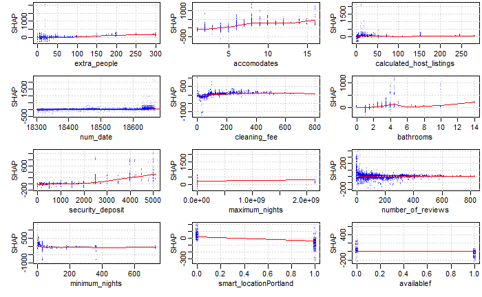

```r
xgb.plot.shap(data = makeX(full_df[test_idx, features], sparse = TRUE),
              model = xgmod,
              top_n = 12,
              n_col = 3,
              plot_loess = TRUE)
```

The model has an out-of-sample R<sup>2</sup> of 0.2707057. Not terrible.

## Predicting Occupancy

We’ll now repeat a similar analysis predicting listing availability over the calendar year.

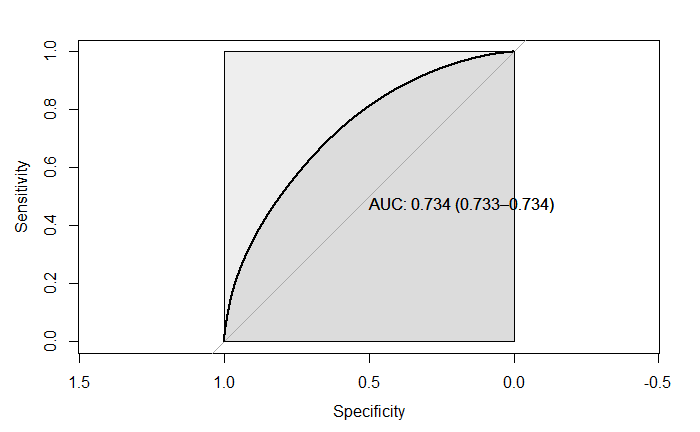

```r
suppressMessages({
  library(xgboost)
  library(glmnet)
  library(mlr)
  library(Ckmeans.1d.dp)
  library(caret)
  library(pROC)
})

#select features and target
features <- c("price","minimum_nights",
              "maximum_nights","accomodates",
              "cleaning_fee","extra_people",
              "number_of_reviews","bathrooms",
              "security_deposit","calculated_host_listings",
              "smart_location", "weekday",
              "is_holiday", "num_date")

#breakup training and test sets
test_frac <- 0.15
train_listings <- c()
for (city in levels(full_df$smart_location)){
  city_listings <- unique(full_df$listing_id[full_df$smart_location == city])
  num_city_listings <- length(city_listings)
  train_listings <- c(train_listings,
                     sample(city_listings,
                            floor(test_frac*num_city_listings),
                            replace = FALSE))
}

#prepare training and test sets for xgboost
train_idx <- as.integer(full_df$listing_id) %in% train_listings
test_idx <- !(as.integer(full_df$listing_id) %in% train_listings)
xgtrain <- xgb.DMatrix(data = makeX(full_df[train_idx, features],
                                    sparse = TRUE),
                       label = as.numeric(full_df$available[train_idx] == 't'))

xgtest <- xgb.DMatrix(data = makeX(full_df[test_idx, features],
                                   sparse = TRUE),
                      label = as.numeric(full_df$available[test_idx] == 't'))

#xgboost cross validation parameters
cvparams <- list(booster = "gbtree",
                 objective = "binary:logistic",
                 eta=0.3,
                 gamma=0,
                 max_depth=10)

#k-fold cross-validated xgboost
#take folds by sampling listings as above
num_folds <- 5
folds <- vector("list", num_folds)
for (fold in 1:num_folds){
  fold_indices <- c()
  for (city in levels(full_df$smart_location)){
    city_listings <- unique(full_df$listing_id[full_df$smart_location[train_idx] == city])
    num_city_listings <- length(city_listings)
    sample_listings <-   sample(city_listings,
                         floor(test_frac*num_city_listings),
                         replace = FALSE)
    fold_indices <- c(fold_indices, which(full_df$listing_id[train_idx] %in% sample_listings))
  }
  folds[[fold]] <- fold_indices
}

xgbcv <- xgb.cv(params = cvparams,
                data = xgtrain,
                nrounds = 300,
                folds = folds,
                showsd = T,
                print_every_n = 10,
                verbose = 0,
                early_stopping_rounds = 20,
                maximize = F)

xgmod <- xgb.train(data = xgtrain,
                  params = cvparams,
                  nrounds = xgbcv$best_iteration,
                  print_every_n = 10,
                  verbose = 0,
                  watchlist = list(val= xgtest,train = xgtrain))

truth <- as.numeric(full_df$available[test_idx] == 't')

#roc plot
invisible(
  roc(truth, predict(xgmod, xgtest),
      smoothed = FALSE,
      ci=TRUE, ci.alpha=0.9,
      plot=TRUE, auc.polygon=TRUE, max.auc.polygon=TRUE, #grid=TRUE,
      print.auc=TRUE, show.thres=TRUE,
      quiet = TRUE)
)
```

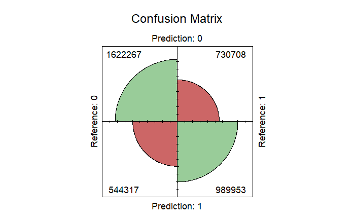

```r
#confusion plot
xgpred <- ifelse (predict(xgmod, xgtest) > 0.5,1,0)
conf_mat <- confusionMatrix(as.factor(xgpred), as.factor(truth))
fourfoldplot(conf_mat$table, color = c("#CC6666", "#99CC99"),
             conf.level = 0, margin = 1, main = "Confusion Matrix")
```

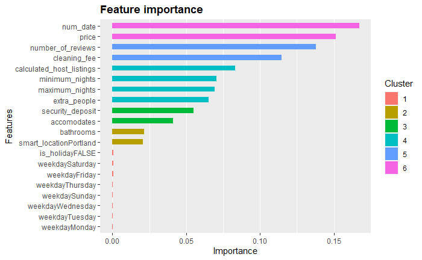

```r
#importance plot
importance <- xgb.importance(feature_names = colnames(xgtrain), model = xgmod)
xgb.ggplot.importance(importance_matrix = importance)
```

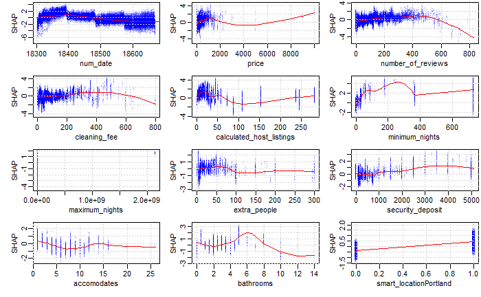

```r
#dependence plots
xgb.plot.shap(data = makeX(full_df[test_idx, features], sparse = TRUE),
              model = xgmod,
              top_n = 12,
              n_col = 3,
              plot_loess = TRUE)
```